# Leveraging Distance Metrics for Better Machine Learning

**Siddharth Chaini, 6th January, 2025**

(Special thanks to Federica Bianco, Ashish Mahabal and Ajit Kembhavi!)

This hands-on session is largely based on and derived from the work described in [Chaini et. al 2024](https://arxiv.org/abs/2403.12120). It will go over:

1. What are distance metrics?
2. Where are they used in machine learning?
3. DistClassiPy
   - Demo on a real astronomical dataset!

### 0. Prerequisites

Let us first install DistClassiPy from PyPI. I am installing 0.2.1, the latest as of 2025-01-05.

```python
!pip install distclassipy==0.2.1 # latest as of 2025-01-05.
```

```
Downloading distclassipy-0.2.1-py3-none-any.whl (43 kB)
  Attempting uninstall: distclassipy
    Found existing installation: distclassipy 0.2.2
    Uninstalling distclassipy-0.2.2:
      Successfully uninstalled distclassipy-0.2.2
```

```python
%%capture
!wget https://github.com/sidchaini/DistClassiPyTutorial/archive/refs/heads/main.zip
!unzip main.zip
!mv DistClassiPyTutorial-main/* .
!rm -rf main.zip DistClassiPyTutorial-main
```

```python
import numpy as np

seed = 0
np.random.seed(seed)
import pandas as pd
import distclassipy as dcpy
import utils
import matplotlib.pyplot as plt
import seaborn as sns
from sklearn.model_selection import train_test_split
from sklearn.metrics import accuracy_score, f1_score
print(f"distclassipy version {dcpy.__version__}")
```

```
distclassipy version 0.2.1
```

### 1. What are distance metrics?

**Definition**: A distance is a quantity that tells us how similar two objects are. It follows the axioms:

1. *Identity of indiscernibles*: $$d(x, y)=0 \iff x=y $$
2. *Symmetry*: $$d(x, y)=d(y, x)$$
3. *Triangle inequality*: $$d(x, y)\leq d(x, z) + d(z, y)$$

**Small exercise**: Which of the following is a distance metric, and which is not? Why?

```python
def custom_fn1(x, y):
    return np.sum(np.abs(x - y))
```

```python
def custom_fn2(x, y):
    return (1 + np.sum(np.abs(x - y)))**2
```

```python
p1 = np.array([1, 2, 3])

custom_fn2(p1, p1) # fails distance metric defn as nonzero
```

```
1
```

```python
print(f"DCPY has {len(dcpy._ALL_METRICS)} metrics")
print(dcpy._ALL_METRICS)
```

```
DCPY has 43 metrics
['euclidean', 'braycurtis', 'canberra', 'cityblock', 'chebyshev', 'clark', 'correlation', 'cosine', 'hellinger', 'jaccard', 'lorentzian', 'marylandbridge', 'meehl', 'motyka', 'soergel', 'wave_hedges', 'kulczynski', 'add_chisq', 'acc', 'chebyshev_min', 'czekanowski', 'dice', 'divergence', 'google', '…
```

**Visualizing 2D distance metric spaces**: We can plot the locus of a central point (*e.g.,*$(5,5)$) in a given two dimensional space. The locus appear as contour lines, which can illustrate geometry of the space when plotted in Euclidean space.

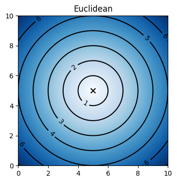

```python
utils.visualize_distance("euclidean")
plt.show()
```

### 2. Distances in Machine Learning

Distance metrics power different ML tasks:

- **Clustering**: Distance metrics help group similar data points (e.g., K-Means, Hierarchical Clustering).
- **Dimensionality Reduction**: They preserve data structure in fewer dimensions (e.g., PCA, t-SNE).
- **Classification**: They determine proximity for decision-making (e.g., K-Nearest Neighbors, SVM, **DistClassiPy**).

```python
from IPython.display import Video
Video(
    "https://sidchaini.github.io/videos/distclassipy.mp4",
    width=480, height=240
)
```

[video not shown]

### 3. DistClassiPy for ZTF Light Curve Classification

For this example, we will be using data from "The ZTF Source Classification Project: III. A Catalog of Variable Sources" through which they have made available on Zenodo.

I downloaded and downsampled them to choose 4000 objects from 4 classes of variable stars:

```python
features = pd.read_csv("data/ztfscope_features.csv", index_col=0)
labels = pd.read_csv("data/ztfscope_labels.csv", index_col=0)
```

```python
labels.value_counts()
```

```
class
CEP      1000
DSCT     1000
RR       1000
RRc      1000
Name: count, dtype: int64
```

For the sake of simplicity, let us focus on three features from the complete ZTF SCoPE features (refer to [Healy et al. 2024](https://arxiv.org/abs/2312.00143) for more details):

- `inv_vonneumannratio`: Inverse of von Neumann ratio ([von Neumann 1941](https://projecteuclid.org/journals/annals-of-mathematical-statistics/volume-12/issue-4/Distribution-of-the-Ratio-of-the-Mean-Square-Successive-Difference/10.1214/aoms/1177731677.full), [1942](https://projecteuclid.org/journals/annals-of-mathematical-statistics/volume-13/issue-1/A-Further-Remark-Concerning-the-Distribution-of-the-Ratio-of/10.1214/aoms/1177731645.full)), which is the ratio of correlated variance and variance - it detects non-randomness, and a high value implies periodic behaviour.
- `norm_peak_to_peak_amp`: Normalized peak-to-peak amplitude [(Sokolovsky et al. 2009)](https://arxiv.org/abs/0901.1064) - it tells us about the source brightness.
- `stetson_k`: Stetson K coefficient ([Stetson 1996](https://iopscience.iop.org/article/10.1086/133808/meta?casa_token=EMo0hxKqIkUAAAAA:b8y8ONGzEQAJq2WJfrCASQt_FMw7HX_h7i-VChDbTYc1ShDkEih4I2Sm184VFLTS1UpDbATGN8GPmTY4YXRG87jP2Q)) is related to the observed scatter - it tells us about the light curve shape.

```python
feature_names = ["inv_vonneumannratio", "norm_peak_to_peak_amp", "stetson_k"]
```

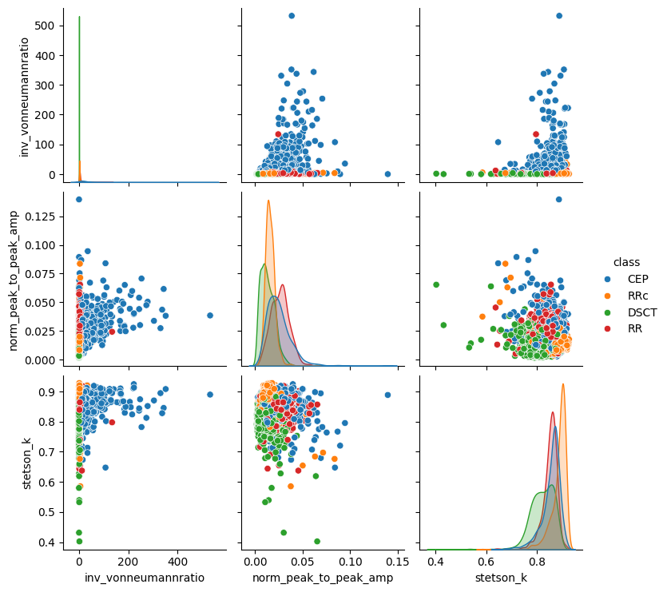

```python
df = features.loc[:, feature_names]
df["class"] = labels["class"]
sns.pairplot(df, hue="class")
plt.show()
```

```python
X = features.loc[:, feature_names].to_numpy()
y = labels.to_numpy().ravel()
```

```python
X_train, X_test, y_train, y_test = train_test_split(
    X, y, test_size=0.25, random_state=seed
)
```

```python
clf = dcpy.DistanceMetricClassifier()
clf.fit(X_train, y_train)
```

```
DistanceMetricClassifier()
```

```python
y_pred = clf.predict_and_analyse(X_test, metric="euclidean")
```

```python
acc = accuracy_score(y_true=y_test, y_pred=y_pred)
f1 = f1_score(y_true=y_test, y_pred=y_pred, average="macro")

print(f"Accuracy = {acc:.3f}")
print(f"F1 = {f1:.3f}")
```

```
Accuracy = 0.642
F1 = 0.635
```

```python
clf.centroid_dist_df_
```

|  | CEP_dist | DSCT_dist | RR_dist | RRc_dist |
| --- | --- | --- | --- | --- |
| 0 | 0.805759 | 2.641208 | 0.824424 | 2.848626 |
| 1 | 1.220526 | 1.423540 | 2.151157 | 1.164521 |
| 2 | 1.325282 | 3.792195 | 1.503853 | 4.076885 |
| 3 | 1.064865 | 8.376741 | 1.781160 | 1.323827 |
| 4 | 0.480929 | 2.229321 | 0.915641 | 2.055988 |
| ... | ... | ... | ... | ... |
| 995 | 1.015133 | 3.548696 | 1.743593 | 0.106400 |
| 996 | 0.957050 | 10.627296 | 1.705001 | 1.205451 |
| 997 | 0.810418 | 14.319456 | 1.574726 | 1.767178 |
| 998 | 1.023541 | 2.556731 | 1.699193 | 0.937611 |
| 999 | 1.452081 | 1.219772 | 2.336256 | 2.059953 |

1000 rows × 4 columns

#### Using multiple distance metrics together!

We can combine multiple distance metrics together!

**Case 1**: Keeping the same set of features, vary the distance metric.

```python
ensemble_clf = dcpy.EnsembleDistanceClassifier(feat_idx=0, random_state=seed)
ensemble_clf.fit(X_train, y_train, n_quantiles=4)
```

```
EnsembleDistanceClassifier(feat_idx=0, random_state=0)
```

```python
y_pred_ensemble = ensemble_clf.predict(X_test)
```

```python
acc = accuracy_score(y_true=y_test, y_pred=y_pred_ensemble)
f1 = f1_score(y_true=y_test, y_pred=y_pred_ensemble, average="macro")

print(f"Accuracy = {acc:.3f}")
print(f"F1 = {f1:.3f}")
```

```
Accuracy = 0.785
F1 = 0.784
```

```python
ensemble_clf.best_metrics_per_quantile_
```

```
Quantile 1                 canberra
Quantile 2                 jeffreys
Quantile 3              wave_hedges
Quantile 4    vicis_symmetric_chisq
dtype: object
```

```python
ensemble_clf.quantile_scores_df_.drop_duplicates()
```

|  | Quantile 1 | Quantile 2 | Quantile 3 | Quantile 4 |
| --- | --- | --- | --- | --- |
| euclidean | 62.765957 | 48.404255 | 48.663102 | 79.679144 |
| braycurtis | 56.382979 | 65.425532 | 66.310160 | 79.679144 |
| canberra | 89.893617 | 72.872340 | 70.588235 | 79.679144 |
| cityblock | 60.638298 | 48.936170 | 51.871658 | 79.679144 |
| chebyshev | 63.829787 | 51.063830 | 50.267380 | 79.679144 |
| clark | 89.893617 | 72.340426 | 71.122995 | 81.818182 |
| correlation | 29.787234 | 37.765957 | 52.941176 | 76.470588 |
| cosine | 54.255319 | 57.446809 | 60.962567 | 79.679144 |
| hellinger | 80.319149 | 72.340426 | 71.122995 | 79.679144 |
| jaccard | 55.851064 | 63.829787 | 66.310160 | 80.213904 |
| lorentzian | 62.234043 | 49.468085 | 52.406417 | 79.679144 |
| marylandbridge | 24.468085 | 30.851064 | 38.502674 | 75.935829 |
| meehl | 49.468085 | 41.489362 | 55.614973 | 79.144385 |
| wave_hedges | 88.829787 | 71.808511 | 72.192513 | 74.866310 |
| add_chisq | 88.297872 | 74.468085 | 70.588235 | 79.679144 |
| acc | 63.297872 | 48.936170 | 51.336898 | 79.679144 |
| chebyshev_min | 60.638298 | 42.021277 | 43.850267 | 55.614973 |
| dice | 2.659574 | 30.319149 | 60.427807 | 29.411765 |
| google | 69.148936 | 65.425532 | 63.101604 | 76.470588 |
| jeffreys | 83.510638 | 75.000000 | 71.122995 | 79.679144 |
| jensenshannon_divergence | 78.723404 | 71.276596 | 71.122995 | 79.679144 |
| kumarjohnson | 89.361702 | 75.000000 | 70.588235 | 79.679144 |
| penroseshape | 40.425532 | 49.468085 | 58.288770 | 79.679144 |
| prob_chisq | 75.531915 | 69.680851 | 71.122995 | 79.679144 |
| taneja | 86.702128 | 75.000000 | 71.122995 | 79.679144 |
| vicis_symmetric_chisq | 89.893617 | 69.148936 | 71.657754 | 82.352941 |
| vicis_wave_hedges | 89.893617 | 71.808511 | 71.657754 | 82.352941 |

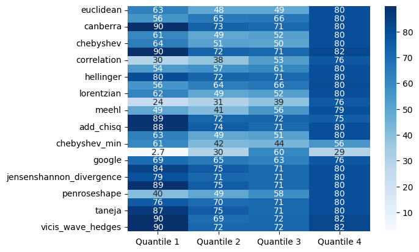

```python
sns.heatmap(
    ensemble_clf.quantile_scores_df_.drop_duplicates(), annot=True, cmap="Blues"
)
plt.show()
```

But what if we also allowed each metric to work with different features?

**Case 2**: Varying the features AND the distance metric.

From our work, we found:

- `We can select a distance metric that works best based on the object of interest!`

```python
# @title
from IPython.display import Image
Image(url="https://arxiv.org/html/2403.12120v2/x31.png",width=480)
```

[figure not shown]

Performance improvement here is much more significant!

If you are interested in more details: